# Auckland flight trends for Qantas

Project 3

500459007

University of Sydney | DATA1001 | November 2020

# 1 Recommendaton

This report is stated for **Qantas Airways** and has an analysis of flights to Auckland from 2003 to 2018.

The recommendation formed after data analysis would be for Qantas to **focus flight routes towards Auckland** due to tourism increase as the city has gained popularity as a highly sought destination.

# 2 Initial Data Analysis

## 2.1 Source of data

The dataset is sourced from the [Australian Government](https://data.gov.au/dataset/ds-dga-e82787e4-a480-4189-b963-1d0b6088103e/details), a legitimate, reliable source of data.

In terms of the data collected, there is a possibility of:

- Human error during entering data in the system
- Miscalculations or misinterpretation of data
- False or invalid data entry

## 2.2 Structure of dataset

The data has **15 variables** with **89312 responses** (objects).

```r
flights_data = read.csv("flights.csv")
dim(flights_data)
```

```
## [1] 89312    15
```

[output not shown]

## 2.3 Limitations of data

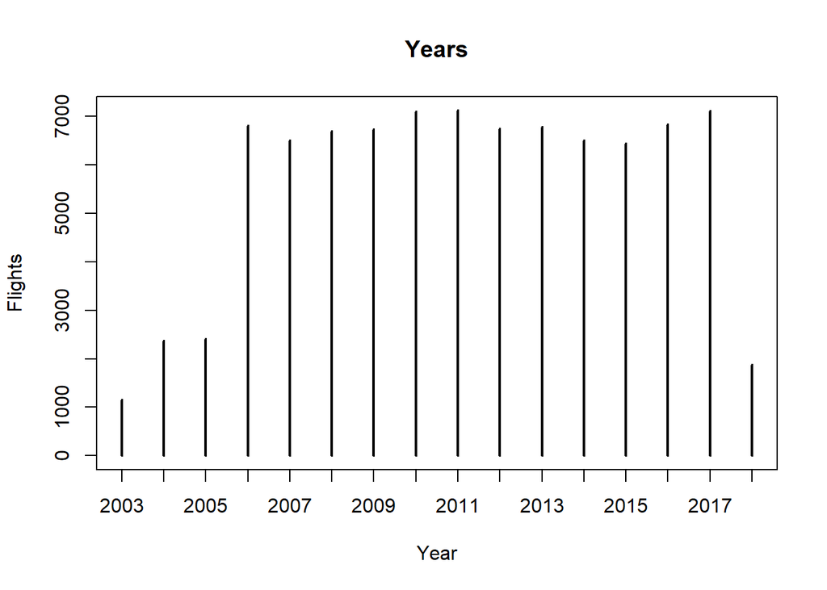

The data was collected over a period of **15 years** (2003 - 2018).

However, it is **not representative of current circumstances** within the airline industry during the COVID-19 pandemic and countries closing borders (confounding variable).

# 3 Evidence

## 3.1 Number of flights

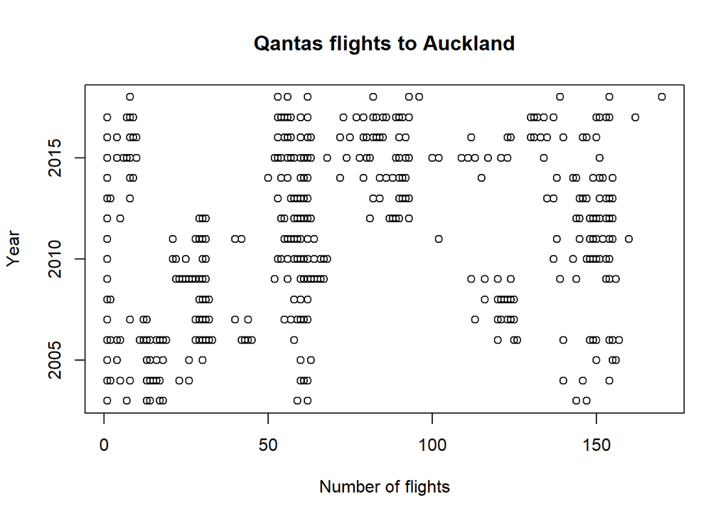

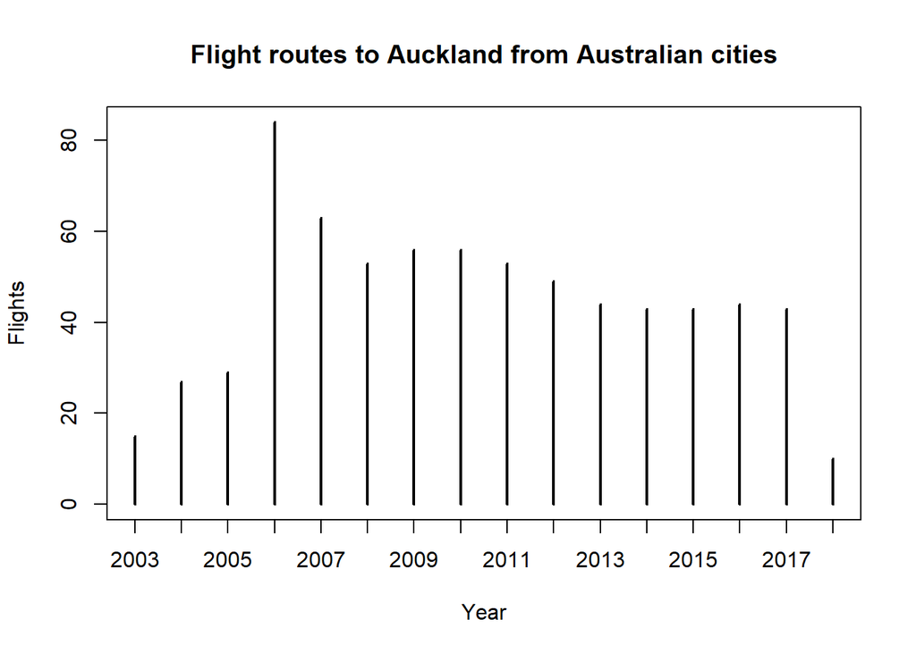

This could indicate that Qantas is aiming to transport *more* passengers with the use of *less* routes, making their fleet and airway **more efficient** in response to higher demand of flights to Auckland.

There is also a drastic drop in routes in the year 2018. This may possibly be due to several factors:

- Drop in flight demand
- Lack of data from 2018

Another factor would include the new partnership formed in 2018 between Qantas and Air NZ, allowing passengers to sit *either* airline to travel between Australia and New Zealand (Lake, 2018). This would’ve gave travellers the choice to choose between flying with Qantas or Air NZ, leading to less passengers opting Qantas.

## 3.2 Number of passengers

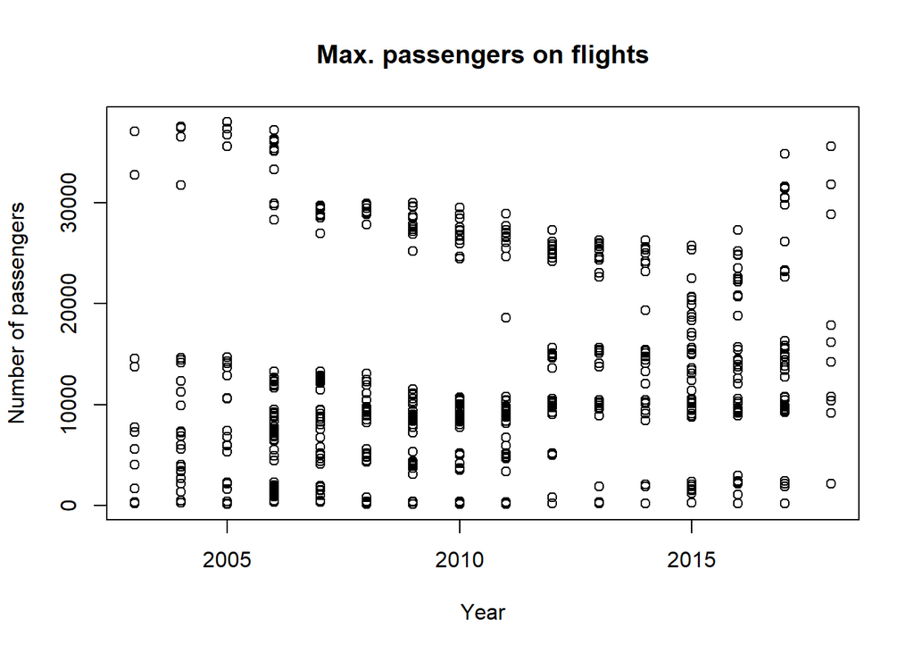

In the early 2000s, it can be seen that most flights have passengers *below* the 15000 capacity mark and only a **small amount of flights** having a **high amount of passengers** (above 30000).

As the years pass, it is evident that flight capacities gradually became **more evenly distributed**, with an **even spread of the capacity** of flights from the year 2012.

Even in the year 2018 with the low number of routes to Auckland, flight capacity distribution *remained*.

This indicates that although Qantas has **less routes**, travel demand to Auckland has **remained the same**, if not developed with a steady range of passenger capacities amongst flight routes.

## 3.3 Mean & Median

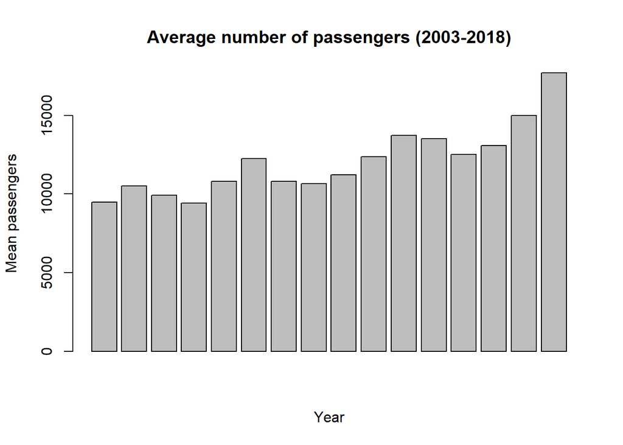

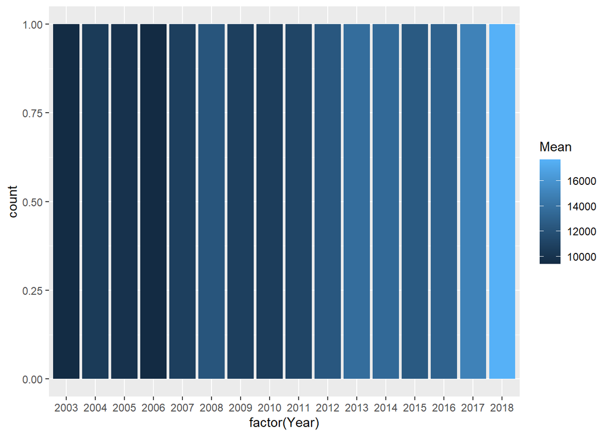

This is heavily indicative that over time, more and **more Australians are seeking to travel to Auckland**. These findings reflect the recommendation of Qantas Airways developing their flight routes *more* towards the city of Auckland as Australians are more than keen in traveling that direction, and have been for some time.

## 3.4 Other Evidence

The increase in travel to Auckland is reflected in an article from 2015 stating Auckland’s tourists has “cracked the two million mark for annual international visitor arrivals for the first time” (Bradley, 2015).

Another source states that Auckland is Qantas Airways’ “most popular international destination due to high transtasman traffic” (Gibson, 2015). This supports the findings and evidence gathered from the datasets and backs the recommendation of Qantas Airways focusing more of their flight routes towards the ever-booming city of Auckland.

# 4 Acknowledgements

I’d like to acknowledge my tutor Jackzon Zhou who answered my [EdStem](https://edstem.org/courses/4447/discussion/338790) query.

# 5 References

Bradley, G. (2015). *Auckland visitors top 2 million.* NZ Herald. Retrieved 3 November 2020, from https://www.nzherald.co.nz/business/auckland-visitors-top-2-million/EAABNIIWDPFI222L4LONROM5QM/.

Gibson, N. (2015). *Carry on: More Air NZ Dreamliners, Qantas’ new Auckland lounge, world’s safest airline.* NBR. Retrieved 5 November 2020, from https://www.nbr.co.nz/article/carry-more-air-nz-dreamliners-qantas-new-auckland-lounge-worlds-safest-airline-ng-167312.

Lake, D. (2018). *Air NZ and Qantas announce new partnership.* Newshub. Retrieved 6 November 2020, from https://www.newshub.co.nz/home/travel/2018/06/airnz-and-qantas-announce-new-partnership.html.

# 6 Data Science Reflection

DATA1001 has helped prepare this report by providing useful lectures and coding guides, advising which graphical/numerical summaries appropriate to represent evidence.

These skills are useful throughout my major as they are fundamental to the core of Data Science, providing essential first steps into a heightened understanding of the course.